# QTM 151 - Introduction to Statistical Computing II

Lecture 09 - Global and Local Variables

Danilo Freire

danilo.freire@emory.edu

Emory University

30 September, 2024

# Hello again! 🥳

# Recap of last class 📚

## In our last class, we learned

- How to write functions with `def` and `return`
- What paratemers, arguments, and return values are
- How to combine functions with `if` statements
- How to use [lambda](https://realpython.com/python-lambda/) to create quick, throwaway functions

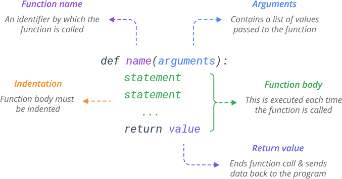

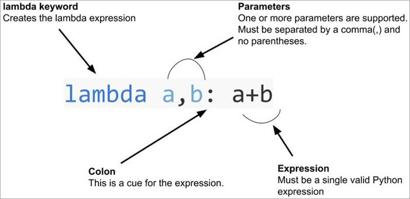

## Today’s plan 📅

- Today, we will learn about [variable scope](https://ksvmuralidhar.medium.com/understanding-the-scope-of-the-variables-in-python-d83a95b73d90) in Python
- Scope is important because it determines the visibility of variables, that is, where you can access them in your code
- We will learn about [local, enclosing, global, and built-in scopes](https://realpython.com/python-scope-legb-rule/)
- We will also learn about the `global` keyword
- We will see how to use the `apply` and `map` functions to apply functions to many variables at once
- Finally, we will learn about `.py` files and how to import them as modules

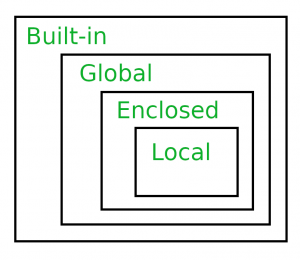

# Understanding scope in Python 🧐

## What is variable scope?

- Scope is the area of a programme where a variable is accessible
- Think of scope as a variable’s “visibility” in different parts of your code
- Python uses the LEGB rule to determine variable scope:
  - Local: Inside the current function
  - Enclosing: Inside enclosing/nested functions
  - Global: At the top level of the module
  - Built-in: In the built-in namespace
- The LEGB rule defines the order Python searches for variables
- It is easier to understand them with an example:

```python
x = 10  # Global scope

def print_x():
    x = 20  # Local scope
    print(x)  # Prints 20 (local)

print_x()

print(x)  # Prints 10 (global)
```

## Global scope

### Variables defined outside a function

- Most variables we have seen so far are in the global scope
  - Example: `x = 10` is a global variable
- They are stored in the global namespace and are accessible from anywhere in the code
- Global variables are created when you assign them values, and are destroyed when you close Python

```python
message_hello = "hello"
number3       = 3

print(message_hello + " world")
print(number3 * 2)
```

```
hello world
6
```

- Global variables can be used in your code, but you should be careful with them when writing functions
- The reason is that functions can change the value of global variables, which can lead to unexpected results
- It is recommended to include all variables that a function needs as parameters

## Global scope

### Recommended and not recommended practices

- Let’s create a function that sums 3 numbers
- $f(x,y,z) = x + y + z$
- We will pass the numbers as arguments to the function

```python
# Correct example:
def fn_add_recommended(x,y,z):
    return(x + y + z)

print(fn_add_recommended(x = 1, y = 2, z = 5))
print(fn_add_recommended(x = 1, y = 2, z = 10))
```

```
8
13
```

- If you do not include the variables as parameters, Python will try to use global variables if they exist

```python
# Incorrect example:
def fn_add_notrecommended(x,y):
    return(x + y + z)

z = 5
print(fn_add_notrecommended(x = 1, y = 2))
z = 10
print(fn_add_notrecommended(x = 1, y = 2))
```

```
8
13
```

```python
del z # Remove variable z from global scope
print(fn_add_notrecommended(x = 1, y = 2))
```

```
NameError: name 'z' is not defined
```

## Local scope

### Variables defined inside a function

- Variables defined inside a function are local to that function
- They are not accessible outside the function
- Local variables are destroyed when the function returns
- If you try to access a local variable outside the function, you will get a `NameError`
- They include parameters and variables created inside the function
- Example:
- In the code below, `x` is a local variable to the function `print_x()`

```python
def print_x():
    x = 20  # Local scope
    print(x)  # Prints 20 (local)

print_x() # Prints 20

print(x)  # NameError: name 'x' is not defined
```

```
>>> print_x()
20
>>> print(x)  # NameError: name 'x' is not defined
Traceback (most recent call last):
  File "<stdin>", line 1, in <module>
NameError: name 'x' is not defined
```

## Local variables supercede global variables

### Remember the LEGB rule

```python
# This is an example where we define a quadratic function
# (x,y) are both local variables of the function
#
# When we call the function, only the arguments matter.
# any intermediate value inside the function

def fn_square(x):
    y = x**2
    return(y)

x = 5
y = -5

print(fn_square(x = 1))

print(x)
print(y)
```

```
1
5
-5
```

## Local variables are not stored in the working environment

```python
# The following code assigns a global variable x
# Inside the function

x = 5
y = 4

print("Example 1:")
print(fn_square(x = 10))
print(x)
print(y)

print("Example 2:")
print(fn_square(x = 20))
print(x)
print(y)
```

```
Example 1:
100
5
4
Example 2:
400
5
4
```

## Permanent changes to global variables

- If you want to change a global variable inside a function, you need to use the `global` keyword
- The `global` keyword tells Python that you want to use the global variable, not create a new local variable

```python
def modify_x():
    global x
    x = x + 5

x = 1

modify_x()
print(x)
```

```
6
```

- I don’t think I have ever used `global` in my code
- It makes the code harder to read and understand
- You should avoid it too 😉

## Try it out! 🚀

```python
def modify_x():
    global x
    x = x + 5

x = 1

modify_x()
print(x)
```

```
6
```

- What happens if we run the function `modify_x()` again?
- What happens if we add `global y` inside `fn_square`?
- Appendix 01

## Built-in scope

### Variables defined in Python

- We have also seen many built-in functions in Python, like `print()`, `len()`, `sum()`, etc
- They are available in any part of your code, and you don’t need to define them
- Python has a list of variables that are always available to prevent you from using the same names
- Most of them are error names

```python
print(len("hello"))

m = min([4, 3, 1, 7])
print(m)
```

```
5
1
```

```python
import builtins

# View a list of attributes of a given object with dir()
print(dir(builtins))
```

```
['ArithmeticError', 'AssertionError', 'AttributeError', 'BaseException', 'BaseExceptionGroup', 'BlockingIOError', 'BrokenPipeError', 'BufferError', 'BytesWarning', 'ChildProcessError', 'ConnectionAbortedError', 'ConnectionError', 'ConnectionRefusedError', 'ConnectionResetError', 'DeprecationWarning'…
```

## Enclosing scope

### Variables defined in enclosing functions

- They are variables defined in enclosing functions
- Enclosing functions are functions that contain other functions (nested functions)
- Enclosing scope is between local and global scopes in the LEGB rule
- They are easier to understand once you understand local and global scopes
- We will not use them much in this course

## Enclosing scope

### Variables defined in enclosing functions

```python
# Define a function that
# contains another function
def outer():
    x = "outer x" # Local to outer()

    # Define a nested function
    def inner():
        x = "inner x" # Local to inner()
        print(x) # Print local to inner()

    inner() # Run inner()
    print(x) # Print local to outer()

outer() # Run outer()
```

```
inner x
outer x
```

```python
# Define a function that
# contains another function
def outer():
    x = "outer x" # Local to outer()

    # Define a nested function
    def inner():
        # x = "inner x"
        print(x) # No local x, so use enclosing x

    inner() # Run inner()
    print(x) # Print local to outer()

outer() # Run outer()
```

```
outer x
outer x
```

# Operations over many variables 🧮

## Pandas

[figure not shown]

- `pandas` is the main library for data manipulation in Python 🐼
- We will use it a lot in this course (and in your life as a data scientist!)
- It is built on top of `numpy` and `matplotlib`, and has [a gazillion functions to work with data](https://pandas.pydata.org/docs/reference/index.html) 😁
- If you use `R` already, think about it as the `dplyr` of Python
  - A list of [equivalences between `dplyr` and `pandas`](https://pandas.pydata.org/docs/getting_started/comparison/comparison_with_r.html)
- We will learn more about it in the next classes

## Applying functions to a dataset

- The `apply` function is used to apply a function to a dataset
  - (This course is full of surprises, isn’t it? 😄)
- It is a method of a pandas DataFrame
- It can be used with built-in functions, custom functions, or lambda functions
  - `df.apply(function)`
- You can apply functions to rows or columns
  - `df.apply(function, axis=0)` applies the function to each column (default)
  - `df.apply(function, axis=1)` applies the function to each row

## Applying functions to a dataset

```python
import numpy as np
import pandas as pd

df = pd.DataFrame({
    'A': [1, 2, 3],
    'B': [4, 5, 6],
    'C': [7, 8, 9]
})

print(df.apply(np.sqrt))
```

```
          A         B         C
0  1.000000  2.000000  2.645751
1  1.414214  2.236068  2.828427
2  1.732051  2.449490  3.000000
```

```python
print(df.apply(np.sum, axis=1))
```

```
0    12
1    15
2    18
dtype: int64
```

```python
print(df.apply(lambda x: x**2))
```

```
   A   B   C
0  1  16  49
1  4  25  64
2  9  36  81
```

## Applying functions to a dataset

- Let’s do a quick exercise

```python
# Create an empty DataFrame
data = pd.DataFrame()

# Add variables
data["age"] = [18,29,15,32,6]
data["num_underage_siblings"] = [0,0,1,1,0]
data["num_adult_siblings"] = [1,0,0,1,0]

display(data)
```

|  | age | num_underage_siblings | num_adult_siblings |
| --- | --- | --- | --- |
| 0 | 18 | 0 | 1 |
| 1 | 29 | 0 | 0 |
| 2 | 15 | 1 | 0 |
| 3 | 32 | 1 | 1 |
| 4 | 6 | 0 | 0 |

- Now let’s define some functions

```python
# The first two functions return True/False depending on age constraints
# The third function returns the sum of two numbers
# The fourth function returns a string with the age bracket

fn_iseligible_vote = lambda age: age >= 18

fn_istwenties = lambda age: (age >= 20) & (age < 30)

fn_sum = lambda x,y: x + y

def fn_agebracket(age):
    if (age >= 18):
        status = "Adult"
    elif (age >= 10) & (age < 18):
        status = "Adolescent"
    else:
        status = "Child"
    return(status)
```

## Applying functions to a dataset

- Now let’s apply the functions to the `data["age"]` column

```python
data["can_vote"]    = data["age"].apply(fn_iseligible_vote)
data["in_twenties"] = data["age"].apply(fn_istwenties)
data["age_bracket"] = data["age"].apply(fn_agebracket)

display(data)
```

|  | age | num_underage_siblings | num_adult_siblings | can_vote | in_twenties | age_bracket |
| --- | --- | --- | --- | --- | --- | --- |
| 0 | 18 | 0 | 1 | True | False | Adult |
| 1 | 29 | 0 | 0 | True | True | Adult |
| 2 | 15 | 1 | 0 | False | False | Adolescent |
| 3 | 32 | 1 | 1 | True | False | Adult |
| 4 | 6 | 0 | 0 | False | False | Child |

## Creating a new variable

- You can also create a new variable using the `apply` function

```python
# Creating a new variable
data["new_var"] = data["age"].apply(lambda age: age >= 18)

display(data)
```

|  | age | num_underage_siblings | num_adult_siblings | can_vote | in_twenties | age_bracket | new_var |
| --- | --- | --- | --- | --- | --- | --- | --- |
| 0 | 18 | 0 | 1 | True | False | Adult | True |
| 1 | 29 | 0 | 0 | True | True | Adult | True |
| 2 | 15 | 1 | 0 | False | False | Adolescent | False |
| 3 | 32 | 1 | 1 | True | False | Adult | True |
| 4 | 6 | 0 | 0 | False | False | Child | False |

## Deleting a variable

- You can also delete a variable using the `drop` function

```python
data = data.drop(columns = ["new_var"])

display(data)
```

|  | age | num_underage_siblings | num_adult_siblings | can_vote | in_twenties | age_bracket |
| --- | --- | --- | --- | --- | --- | --- |
| 0 | 18 | 0 | 1 | True | False | Adult |
| 1 | 29 | 0 | 0 | True | True | Adult |
| 2 | 15 | 1 | 0 | False | False | Adolescent |
| 3 | 32 | 1 | 1 | True | False | Adult |
| 4 | 6 | 0 | 0 | False | False | Child |

## Mapping functions to a list, array, or series

- The `map` function is used to apply a function to a list, an array, or a series
  - A series is a single column of a pandas DataFrame
- In pandas, `map` works very similarly to the `apply` function, and they are interchangeable when working with series
- `map` can be faster than `apply` for simple functions, but `apply` is more flexible as it can be used with DataFrames (many columns)
- However, if you are using regular lists (e.g., `list01 = [1,2,3]`), you should use `map` instead of `apply`
  - `apply` is not a built-in Python function

```python
data["age_bracket01"] = data["age"].map(fn_agebracket)

display(data[["age","age_bracket01"]])
```

|  | age | age_bracket01 |
| --- | --- | --- |
| 0 | 18 | Adult |
| 1 | 29 | Adult |
| 2 | 15 | Adolescent |
| 3 | 32 | Adult |
| 4 | 6 | Child |

```python
data["age_bracket02"] = data["age"].apply(fn_agebracket)

display(data[["age","age_bracket02"]])
```

|  | age | age_bracket02 |
| --- | --- | --- |
| 0 | 18 | Adult |
| 1 | 29 | Adult |
| 2 | 15 | Adolescent |
| 3 | 32 | Adult |
| 4 | 6 | Child |

## Mapping functions to a list, array, or series

- Using `map` with a list and an array

```python
# Create a list
list01 = [1,2,3,4,5]

# Map a function to the list
list02 = list(map(lambda x: x**2, list01))

print(list02)
```

```
[1, 4, 9, 16, 25]
```

```python
# Create a numpy array
array01 = np.array([1,2,3,4,5])

# Map a function to the array
array02 = np.array(list(map(lambda x: x**2, array01)))

print(array02)
```

```
[ 1  4  9 16 25]
```

- Trying to use `apply` with a list or an array will raise an error

```python
# Create a list
list01 = [1,2,3,4,5]

# Apply a function to the list
list02 = list(apply(lambda x: x**2, list01))

print(list02)
```

```
---------------------------------------------------------------------------
NameError                                 Traceback (most recent call last)
Cell In[168], line 5
      2 list01 = [1,2,3,4,5]
      4 # Apply a function to the list
----> 5 list02 = list(apply(lambda x: x**2, list01))
      7 print(list02)

NameError: name 'apply' is not defined
```

## Try it yourself! 🚀

- Write a lambda function checking whether `num_siblings` $\ge 1$
- Add a variable to the dataset called `has_siblings`
- Assign True/False to this variable using `apply()`
- Appendix 02

## Try it yourself! 🚀

- Read the car dataset `data_raw/features.csv`
- Create a function that tests whether `mpg` $\ge$ 29
- Add a variable `mpg_above_29` which is `True/False` if `mpg` $\ge$ 29
- Store the new dataset to `data_clean/features.csv`
- Appendix 03

## Try it yourself! 🚀

### Last exercise of the day! 🏁

- Create a lambda function with arguments `{fruit,color}`
- The function returns the string `"A {fruit} is {color}"`
- Create the following two lists:
  - `list_fruits = ["banana","strawberry","kiwi"]`
  - `list_colors = ["yellow","red","green"]`
- Use the `list(map())` function to output a list with the form
- `["A banana is yellow","A strawberry is red","A kiwi is green"]`
- Appendix 04

# Importing modules 📦

## Importing modules

### What is a module?

- While `.ipynb` files are great for learning and teaching, they are not the best for sharing code
- When you write a lot of functions, you should save them in a `.py` file, which is a Python script
- A Python script, or module, is just a file containing Python code
- This code can be functions, classes, or variables
- A folder containing Python scripts is called a package
- You can import modules to use their code in your own code
- We can import functions into the working environment from a file

```python
# Import the folder `scripts` as a package
# And the file `example_functions.py` as `ef`
import scripts.example_functions as ef

print(ef.fn_quadratic(2))
print(ef.fn_cubic(3))

ef.message_hello("Juan")
```

```
4
27
```

```
'hi Juan'
```

## Importing modules

### Importing variables

- You can also import variables from a module
- However, it is not recommended to import variables
- It is better to import functions and use them to create variables
- This is because variables can be changed in the module, leading to unexpected results
- Example:

```python
import scripts.example_variables as ev

# When we run this code
# the value of alpha will be overwritten

alpha = 1
print(alpha)
print(ev.alpha)

from scripts.example_variables import *

print(alpha)
print(beta)
print(gamma)
print(delta)
```

```
1
5
5
10
20
100
```

# And that’s it for today! 🎉

# Thanks very much! 😊

## Appendix 01

```python
def modify_x():
    global x
    x = x + 5

x = 1

# Now, running the function
# will permanently increase x by 5.

modify_x()
print(x)
modify_x()
print(x)
```

```
6
11
```

```python
def fn_square(x):
    global y
    y = x**2
    return(y)

x = 5
y = -5

print("Example 1:")
print(fn_square(x = 10))
print(x)
print(y)
```

```
Example 1:
100
5
100
```

Back to exercise 01

## Appendix 02

- Write a lambda function checking whether `num_siblings` $\ge 1$
- Add a variable to the dataset called `has_siblings`
- Assign True/False to this variable using `apply()`

```python
fn_has_siblings = lambda num_siblings: num_siblings >= 1

data["has_siblings"] = data["num_adult_siblings"].apply(fn_has_siblings)

display(data[["num_adult_siblings","has_siblings"]])
```

|  | num_adult_siblings | has_siblings |
| --- | --- | --- |
| 0 | 1 | True |
| 1 | 0 | False |
| 2 | 0 | False |
| 3 | 1 | True |
| 4 | 0 | False |

Back to exercise 02

## Appendix 03

- Read the car dataset `data_raw/features.csv`
- Create a function that tests whether `mpg` $\ge$ 29
- Add a variable `mpg_above_29` which is `True/False` if `mpg` $\ge$ 29
- Store the new dataset to `data_clean/features.csv`

```python
data_raw = pd.read_csv("data_raw/features.csv")

data_raw["mpg_above_29"] = data_raw["mpg"].apply(lambda mpg: mpg >= 29)

display(data_raw[["mpg","mpg_above_29"]])

data_raw.to_csv("data_clean/features.csv", index = False)
```

|  | mpg | mpg_above_29 |
| --- | --- | --- |
| 0 | 18.0 | False |
| 1 | 15.0 | False |
| 2 | 18.0 | False |
| 3 | 16.0 | False |
| 4 | 17.0 | False |
| ... | ... | ... |
| 393 | 27.0 | False |
| 394 | 44.0 | True |
| 395 | 32.0 | True |
| 396 | 28.0 | False |
| 397 | 31.0 | True |

398 rows × 2 columns

Back to exercise 03

## Appendix 04

- Create a lambda function with arguments `{fruit,color}`
- The function returns the string `"A {fruit} is {color}"`
- Create the following two lists:
  - `list_fruits = ["banana","strawberry","kiwi"]`
  - `list_colors = ["yellow","red","green"]`
- Use the `list(map())` function to output a list with the form
- `["A banana is yellow","A strawberry is red","A kiwi is green"]`

```python
fn_fruitcolor = lambda fruit, color: print("A " + fruit + " is " + color)

list_fruits  = ["banana","strawberry","kiwi"]
list_colors  = ["yellow","red","green"]

list(map(fn_fruitcolor, list_fruits, list_colors))
```

```
A banana is yellow
A strawberry is red
A kiwi is green
```

```
[None, None, None]
```

Back to exercise 04

[Global and Local Vars](https://raw.githack.com/danilofreire/qtm151/main/lectures/lecture-09/09-global-local.html)